# reanalyze flow cytometry data from 2021-04-02

Bin He

```r
suppressPackageStartupMessages(require(tidyverse))
suppressPackageStartupMessages(require(cowplot))
```

# Overview

This is a reanalysis of Jia and Lindsey’s 2021-04-02 data, using a series of chimeric Pho4-mNeon with PHO5pr-mCherry strains. The difference in this analysis is that instead of using the Attune software to gate the populations and export the median fluorescence, I developed an R-based analysis pipeline that takes FCS files as input and go through a series of manually or automatically implemented gating steps before calculating the median of the normalized RFP (mCherry/mNeon for each cell). Here I’d like to see if this new pipeline lead to any changes in the conclusions.

## Previous results

In the latest experiment [2021-03-09](https://rpubs.com/emptyhb/jia-lindsey-pho4-chimera-test-20210310) we found several issues, including strain growth defects especially in the *pho2∆* background, and that all chimera tested appear to be Pho2-dependent, in contrast to previous and recent phosphatase plate assay results. Part of the reason some of these chimera show little activity in *pho2∆* background is due to the apparently higher expression level of the chimera in that background.

*TODO from last experiment*

1. Investigate the effect of growth media (adenine and phosphate levels) on Pho4 chimera expression in *pho2∆* strains.
2. Use Western to confirm whether the higher Pho4 abundance for some chimera in *pho2∆* is real, e.g. pH177
3. Repeat this experiment to determine if the observations are reproducible.
4. Validate the flow cytometry results with phosphatase assay (only works for yH295,6 parents)

## Changes in the 2021-04-02 experiment

- Added pH124 in *pho2∆* background, which is useful for determining the activity of ScPho4 w/o Pho2. But more replicates are needed.
- Jia should include yH296/295, i.e. the host strains, into the experiment.
- A few samples with pH179 in *PHO2* wild type background didn’t grow well, similar to our observation last time.
- The overall pattern of Pho4-chimera expression and normalized chimera activity with and without Pho2 are similar to the last experiment, which is to say the issues we raised in the previous experiment do need to be addressed.

# Material and methods

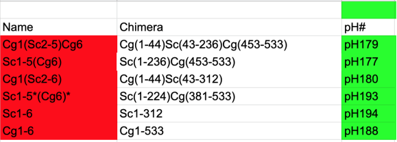

**Figure 1. Pho4 chimera genotypes and the corresponding plasmid ID used in this experiment.**

All strains in the table below have *pho80::Trp1*

```r
samples <- read_csv("../../data/20210402-Lindsey-Jia-test-autosampler-sample-list.csv", col_types = "ccccclc")
samples
```

| Sample | Group | Pho4 | Tag | Content | Pho2 | PHO5RFP |
| --- | --- | --- | --- | --- | --- | --- |
| yH156 | LFS | ScPho4 | NA | Sc(1-312) | TRUE | NA |
| yH372 | LFS | pho4del | NA | pho4del | TRUE | pho5 |
| yH373 | LFS | pho4del | NA | pho4del | FALSE | pho5 |
| 180w | LFS | pH180 | mNeon | Cg(1-44)Sc(43-312) | TRUE | pho5 |
| 180wo | LFS | pH180 | mNeon | Cg(1-44)Sc(43-312) | FALSE | pho5 |
| 177w | LFS | pH177 | mNeon | Sc(1-236)Cg(453-533) | TRUE | pho5 |
| 177wo | LFS | pH177 | mNeon | Sc(1-236)Cg(453-533) | FALSE | pho5 |
| 188w | LFS | pH188 | mNeon | Cg(1-533) | TRUE | pho5 |
| 188wo | LFS | pH188 | mNeon | Cg(1-533) | FALSE | pho5 |
| 193w | LFS | pH193 | mNeon | Sc(1-224)Cg(381-533) | TRUE | pho5 |

[output cut: 19 more lines]

Cells carrying Pho4-chimera plasmids (Leu2+) are first grown to saturation o/n in SD-leu, diluted in the morning to OD~0.2 in SD-leu and regrown for ~2 doublings. Control strains such as yH156 and yH372,373 are grown the same way, only that SC media is used instead. After the culture reached desired OD (mid log phase), cells were spun down and resuspended in PBS and used for flow cytometry. Voltages used are:

| Detector | Voltage | Comments |
| --- | --- | --- |
| FSC | 350 mV | I normally use 285 mV |
| SSC | 350 mV | NA |
| BL1 | 400 mV | NA |
| YL2 | 450 mV | higher than mine |

# Analysis

## Data

```r
dat0.A <- read_csv("20210416-bin-reexported-results.csv") # Attune exported data
dat0.R <- read_tsv("20210930-jz-lfs-gated-median-out.txt") # R-based pipeline output
```

Compare the two sets of results. First reformat each one to make the comparisons possible.

```r
# to make the previous data format the same as the new
dat0.A.wide <- dat0.A %>%
  select(-CV, -rCV, -FP) %>%
  pivot_wider(names_from = Parameter, values_from = Median)
dat0.R.long <- dat0.R %>%
  mutate(Group = factor(Group, levels = c("LFS", "JZ"), labels = c("Lindsey", "Jia")),
         Pho2 = factor(Pho2, levels = c(TRUE, FALSE), labels = c("ScPho2", "pho2del")),
         ID = gsub(".fcs", "", name)) %>%
  select(Group, ID, Sample = strain, Pho4, Pho2, PHO5RFP, Count = n_induction, BL1.H, YL2.H) %>%
  pivot_longer(cols = BL1.H:YL2.H, names_to = "Parameter", values_to = "Median") %>%
  mutate(Parameter = factor(Parameter, levels = c("BL1.H", "YL2.H"), labels = c("Pho4-GFP-H", "PHO5pr-mCherry-H")))
dat0.combine <- dat0.A %>%
  select(-Perc_gated, -CV, -rCV, -Rep) %>%
  full_join(dat0.R.long, by = c("Group", "ID", "Sample", "Pho4", "Pho2", "PHO5RFP", "Parameter"), suffix = c(".A",".R"))
```

And plot the two datasets

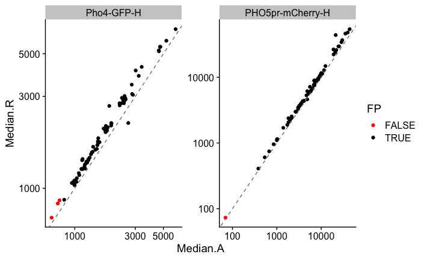

```r
p <- dat0.combine %>%
  ggplot(aes(x = Median.A, y = Median.R)) + geom_point(aes(color = FP)) +
  geom_abline(slope = 1, intercept = 0, linetype = 2, color = "gray50") +
  facet_wrap(~Parameter, scales = "free") + scale_color_manual(values = c("red", "black")) +
  scale_x_log10() + scale_y_log10() + theme_cowplot()
p
```

*Conclusions*

The R pipeline performed comparably to the manually gated data. The good news is, we can use it going forward. However, my initial suspicion that the last gate to select a homogeneous population on BL1.H and YL2.H didn’t really change the values, which is not surprising as the gating stats showed that >90% of the events in most samples are in the main population. So it’s not like we have excluded a large number of events with that.

## Quality control

A few strains didn’t grow well, including

```r
issues <- dat0.R %>% filter(n_induction < 10000) %>% pull(strain)
samples %>% filter(Sample %in% issues)
```

| Sample | Group | Pho4 | Tag | Content | Pho2 | PHO5RFP |
| --- | --- | --- | --- | --- | --- | --- |
| 179w | LFS | pH179 | mNeon | Cg(1-44)Sc(43-236)Cg(453-533) | TRUE | pho5 |
| B3 | JZ | pH179 | mNeon | Cg(1-44)Sc(43-236)Cg(453-533) | TRUE | ura3 |

So the problem is with pH179 (Cg1Sc2-5Cg6) in the *PHO2* wild type background.

Also check the robust CV to identify any samples with unusally high variability within the sample

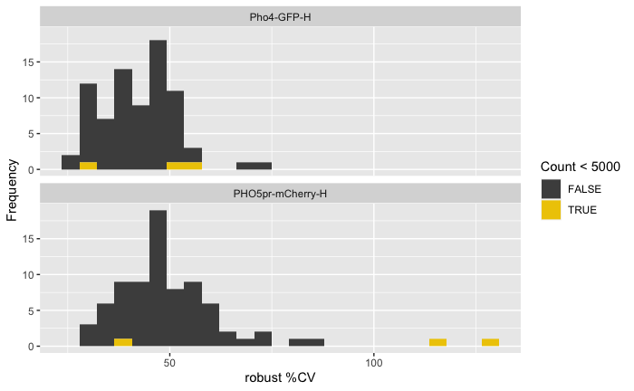

```r
qplot(x = rCV, data = dat0.A, geom = "histogram", bins = 25, fill = Count < 5000) +
  xlab("robust %CV") + ylab("Frequency") +
  facet_wrap(~ Parameter, nrow = 2) +
  scale_fill_manual(values = c("grey30","gold2"))
```

```r
dat <- dat0 %>%
  mutate(flag = ifelse(Count < 5000 | rCV > 75, TRUE, FALSE))
```

## Analysis

### Pho4-GFP expression levels

First look at the background fluorescence level in the GFP channel

```r
gfp.bg <- dat %>% filter(!FP, Parameter == "Pho4-GFP-H") %>% pull(Median) %>% mean()
p0 <- dat %>%
  filter(!FP, Parameter == "Pho4-GFP-H") %>%
  ggplot(aes(x = Sample, y = Median)) + geom_col(position = position_dodge()) +
  geom_hline(yintercept = gfp.bg, linetype = "dashed", alpha = 0.6) +
  labs(title = "Background GFP level") + ylab("MFI") + ylim(c(0, 6000)) +
  theme_cowplot() + theme(axis.text.x = element_text(angle = 90),
                          plot.title = element_text(hjust = 0.5))
p0
```

[output not shown]

It’s good to see that all the negative strains have the same level of background in the BL1 (GFP) channel. Unfortunately we didn’t include any strain that have strong RFP but no GFP so as to evaluate the spillover of the RFP signal into the GFP channel.

Next, we can examine the Pho4-GFP levels for the different constructs, in *PHO2* or *pho2∆* backgrounds, and transformed into two genetic backgrounds.

```r
p1 <- dat %>% filter(FP, Parameter == "Pho4-GFP-H") %>%
  ggplot(aes(x = Pho4, y = Median, alpha = Group)) +
  geom_bar(aes(fill = Pho4), stat = "identity", position = position_dodge2(.9)) +
  geom_text(aes(label = ifelse(flag, "*","")), alpha = 1, size = 5, position = position_dodge2(.9)) +
  stat_summary(fun = "mean", geom = "crossbar", colour = "red", size = 0.2,
               position = position_dodge2(.9), show.legend = F) +
  geom_hline(yintercept = gfp.bg, linetype = "dashed", alpha = 0.6) +
  scale_alpha_discrete("User", range = c(0.5, 1)) +
  facet_wrap(~Pho2, nrow = 1, scales = "free_x") +
  ylab("MFI") + scale_y_continuous(expand = expansion(mult = c(0.01,0.1))) +
  labs(title = "GFP fluorescent intensity (arbitrary units)") +
  theme_cowplot() + theme(axis.text.x = element_text(angle = 40, vjust = 1, hjust = 1)) +
  background_grid(major = "y", minor = "y", size.major = 0.4)

p1
```

[output not shown]

**Figure 4. Pho4-chimera abundance measured by mNeon fluorescent intensity.** Dotted line indicates the background level of GFP. Each bar represents one biological replicate. Jia and Lindsey’s samples were grouped by the plasmid they contain and arranged side-by-side to show their similarity or difference. The red lines indicate the mean for each group.

*Discussion*

- The overall trend is similar to what we saw in the [last experiment](https://rpubs.com/emptyhb/jia-lindsey-pho4-chimera-test-20210310), i.e. significant variability among the chimera, with pH177 showing the highest expression level by fluorescent protein abundance specifically in the *pho2∆* background.
- Different from last time however, there doesn’t appear to be more Pho4 chimera expressed in the *pho2∆* background compared with in the *PHO2* wild type background, except for pH177.
- Only one replicate of pH124, precluding conclusions about its Pho4 expression and activity w/ and w/o Pho2.

### PHO5p-RFP reporter expression

```r
rfp.bg <- dat %>% filter(!FP, Parameter == "PHO5pr-mCherry-H") %>% pull(Median) %>% mean()
rfp.basal <- dat %>% filter(FP, Parameter == "PHO5pr-mCherry-H", Pho4 == "pho4del") %>% pull(Median) %>% mean()
dat %>%
  filter(Parameter == "PHO5pr-mCherry-H", xor(!FP, Pho4 == "pho4del")) %>%
  ggplot(aes(x = Sample, y = Median)) + geom_col(position = position_dodge()) +
  ylim(c(0, 6000)) + ylab("Median Fluorescent Intensity") +
  theme_cowplot()
```

[output not shown]

```r
p1 <- dat %>%
  filter(FP, Pho4 != "pho4del") %>%
  mutate(MFI = Median / 1000) %>%
  ggplot(aes(x = Pho4, y = MFI, alpha = Group)) +
  scale_alpha_discrete("User", range = c(0.5, 1)) +
  geom_col(aes(fill = Pho4), position = position_dodge2(0.9)) +
  geom_text(aes(label = ifelse(flag, "*","")), alpha = 1, size = 5, position = position_dodge2(.9)) +
  geom_hline(aes(yintercept = ifelse(Parameter == "Pho4-GFP-H", gfp.bg/1000, rfp.basal/1000)), linetype = 2, alpha = 0.6) +
  facet_grid(Pho2 ~ Parameter, scales = "free", space = "free_y") + ylab("Median Fluorescent Intensity (x1000)") +
  #scale_color_brewer(type = "qual") + scale_color_manual(values = c("red", NA)) +
  coord_flip() + scale_y_continuous(expand = expansion(mult = c(0.01,0.1))) +
  theme_cowplot() + background_grid(major = "x", minor = "x") + panel_border()
p1
```

[output not shown]

*Discussion*

- For CgPho4 (pH188), the PHO5pr-mCherry reporter levels are comparable in *pho2∆* vs *PHO2* wild type backgrounds, while for ScPho4 (pH194), the reporter level without Pho2 is clearly the lowest compared with all the chimera and CgPho4.
- pH124 showed unexpected results. It is supposed to carry a pRS315-ScPho4-mNeon plasmid and should behave similarly to pH194, and yet the results here suggest that it drove expression of the reporter without Pho2 but didn’t induce expression with Pho2. I suspect the two samples have been labeled wrong.

### Normalized Pho4 chimera activity with and without Pho2

We will first transform the raw GFP and RFP intensities to make them more interpretable. For the GFP intensity, as there is a substantial background, we will subtract the background from all the GFP-containing strains to obtain the meaningful measure for Pho4 protein levels. For RFP, we will similarly subtract the background, which is minimal (~100 a.u. w/o mCherry reporter). Since what we are interested in is not the absolute level of reporter expression but the fold induction compared with the *pho4∆* strains, we will divide the background subtracted RFP levels in the experimental strain by the basal expression level. Then, the induction fold change, call it M, is a function of both Pho4 chimera’s activity (A) in each strain and also the protein level of the chimera (C) (other factors matter, too, but we assume they are the same among all strains for simplicity). We will further assume that M is proportional to both S and C (may not be correct), which leads to $M = kSA$. Rearranging this equation, we get the quantity we are interested in, i.e. activity, as $A/k = M/S$. Since $k$ is a constant and we are only interested in the relative values of activity among the chimera, we can let $A' = A/k$, and for simplicity, we will equate $A'$ with $A$ below.

```r
dat1 <- dat %>%
  # remove all the control strains, including the parents, and only retain the experimental ones
  filter(FP, Pho4 != "pho4del") %>%
  select(Group, Sample, Rep, Pho4, Pho2, Pho5RFP, Parameter, Median) %>%
  pivot_wider(names_from = Parameter, values_from = Median) %>%
  mutate(GFP.noBG = `Pho4-GFP-H` - gfp.bg,
         RFP.noBG = `PHO5pr-mCherry-H` - rfp.bg,
         RFP.FC = RFP.noBG / rfp.basal,
         nRFP.FC = RFP.FC / GFP.noBG * median(GFP.noBG, na.rm = T))
```

Here are the Chimera genotypes again:

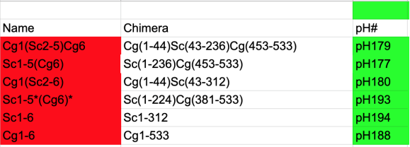

```r
p2 <- dat1 %>%
  pivot_longer(cols = c(RFP.FC, nRFP.FC), names_to = "Parameter", values_to = "Value") %>%
  mutate(Parameter = factor(Parameter, levels = c("RFP.FC", "nRFP.FC"),
                            labels = c("PHO5 fold induction", "PHO5 induction / Pho4-GFP"))) %>%
  ggplot(aes(x = Pho4, y = Value, fill =  Pho4, alpha = Group)) + scale_alpha_discrete("User", range = c(0.5, 1)) +
  geom_col(position = position_dodge2(width = 0.9, preserve = "total")) +
  stat_summary(fun = "median", geom = "crossbar", position = position_dodge2(width = 0.9),
               color = "red", size = 0.3, show.legend = F) +
  #geom_text(aes(label = ifelse(Sample %in% issues, "*", ""), hjust = -0.2, vjust = 0.8), color = "black", size = 5) +
  geom_hline(yintercept = 1, linetype = 2) +
  facet_grid(Pho2 ~ Parameter, scales = "free", space = "free_y") +
  #scale_fill_brewer(type = "div", drop = F) + scale_color_manual(values = c("red", NA)) +
  coord_flip() + scale_y_continuous(expand = expansion(mult=c(0.01,0.1))) + ylab("Fold Induction") + xlab("") +
  theme_bw()

p2
```

[output not shown]

*Discussion*

- As mentioned above, the w/ and w/o Pho2 strains containing pH124 may have been mixed up as they show the opposite pattern than expected.
- Lindsey’s strains appear to give higher normalized activity in the *PHO2* wild type background compared with Jia’s.
- We need a better measurement of the ScPho4 behavior without Pho2. pH194 showed high variability in the RFP channel in Lindsey’s samples and thus the results are difficult to compare with previous ones.

### Plot Pho2-dependence on a scatter plot

Here we want to put each Pho4 chimera on a 2D scatter plot, where the x-axis values represent their activity **with Pho2** and the y-axis values their activity **without Pho2**.

```r
dat2 <- dat1 %>%
  group_by(Group, Sample, Pho4, Pho2) %>%
  summarize(mean = mean(nRFP.FC), sd = sd(nRFP.FC), .groups = "drop") %>%
  pivot_wider(id_cols = c(Group, Pho4), names_from = Pho2, values_from = c(mean, sd))
```

```r
dat2 %>%
  ggplot(aes(x = mean_ScPho2, y = mean_pho2del, color = Pho4, shape = Group)) +
  geom_point(size = 2.5) +
  geom_errorbar(aes(xmin = mean_ScPho2 - sd_ScPho2, xmax = mean_ScPho2 + sd_ScPho2), color = "grey20", size = 0.2, width = 1) +
  geom_errorbar(aes(ymin = mean_pho2del - sd_pho2del, ymax = mean_pho2del + sd_pho2del), color = "grey20", size = 0.2, width = 1) +
  geom_abline(slope = 1, intercept = 0, linetype = 2, color = "grey20") +
  xlab("Activity with Pho2") + ylab("Activity without Pho2")
```

[output not shown]